```python
import pandas as pd
import matplotlib.pyplot as plt
```

```python
drug_data = pd.read_csv('./fda_data_csv/drug_data.csv')
```

```python
drug_data = drug_data.drop(['Unnamed: 0'], axis=1)
```

# Initial exploration

First, the idea is to explore basic stats for the data. The raw data frame "key" can be considered the report ID ('rep_id'). The length of the whole data frame is:

```python
len(drug_data)
```

```
53948707
```

```python
list(drug_data.columns.values)
```

```
['rep_id',
 'primary_source_country',
 'occur_country',
 'patient_onset_age',
 'patient_weight',
 'patient_sex',
 'drug_indication',
 'drug_name',
 'active_substance',
 'receipt_date']
```

# Deduping - drug entries

There seems to be multiple entries related to each report and drug -> removing duplicates

```python
drug_count_df = drug_data.drop_duplicates(subset=drug_data.columns.values, keep=False)
```

```python
drug_count_df.head()
```

|  | rep_id | primary_source_country | occur_country | patient_onset_age | patient_weight | patient_sex | drug_indication | drug_name | active_substance | receipt_date |
| --- | --- | --- | --- | --- | --- | --- | --- | --- | --- | --- |
| 0 | 9009408 | US | US | NaN | NaN | 2.0 | PRODUCT USED FOR UNKNOWN INDICATION | REBIF | NaN | 20130111 |
| 3 | 9047405 | US | US | 60.0 | NaN | 1.0 | RHEUMATOID ARTHRITIS | HUMIRA | NaN | 20130201 |
| 4 | 9055114 | US | US | 54.0 | NaN | 1.0 | NaN | ATROVENT | NaN | 20130206 |
| 5 | 9063060 | US | US | 50.0 | 93.52 | 1.0 | PSORIASIS | HUMIRA 40 MG/ 0.8 ML PRE-FILLED SYRINGE | NaN | 20130129 |
| 6 | 9063060 | US | US | 50.0 | 93.52 | 1.0 | PRODUCT USED FOR UNKNOWN INDICATION | CLOBEX | NaN | 20130129 |

```python
len(drug_count_df)
```

```
47479360
```

There are many distinct drug names, but it seems that the active substance field is more accurate as a drug can have many names, but the substance field is consistent.

```python
deduped_drug_df = drug_count_df
deduped_drug_df['drug_name'].nunique()
```

```
744335
```

```python
deduped_drug_df['active_substance'].nunique()
```

```
12716
```

# Deduping - drug indication

It also appears that the same drug in a report can be linked to multiple indications. This should be deduped or standardized if we want to focus on the drugs

```python
drug_agg_df = deduped_drug_df.groupby(by=['rep_id', 'primary_source_country', 'occur_country',
       'patient_onset_age', 'patient_weight', 'patient_sex','receipt_date', 'active_substance', 'drug_name'],dropna=False).count()
```

```python
drug_agg_df=drug_agg_df.reset_index()
drug_agg_df[drug_agg_df['drug_indication'] > 2]
```

|  | rep_id | primary_source_country | occur_country | patient_onset_age | patient_weight | patient_sex | receipt_date | active_substance | drug_name | drug_indication |
| --- | --- | --- | --- | --- | --- | --- | --- | --- | --- | --- |
| 738 | 4024613 | JP | JP | 17.0 | NaN | 2.0 | 20151027 | DICLOFENAC SODIUM | VOLTAREN | 3 |
| 1895 | 5722762 | US | US | 33.0 | 120.63 | 2.0 | 20160926 | METFORMIN HYDROCHLORIDE | GLUCOPHAGE XR | 3 |
| 2481 | 5805358 | US | US | 42.0 | 78.46 | 1.0 | 20130215 | NaN | ZOMETA | 3 |
| 2495 | 5805863 | US | US | 33.0 | 72.56 | 2.0 | 20151225 | ARIPIPRAZOLE | ABILIFY | 3 |
| 2659 | 5837846 | US | US | 23.0 | NaN | 2.0 | 20160129 | ARIPIPRAZOLE | ABILIFY | 3 |
| ... | ... | ... | ... | ... | ... | ... | ... | ... | ... | ... |
| 44093059 | 9998254 | US | US | NaN | NaN | 1.0 | 20140311 | NaN | MAGNEVIST | 5 |
| 44093064 | 9998254 | US | US | NaN | NaN | 1.0 | 20140311 | NaN | OMNISCAN | 4 |
| 44094160 | 9999806 | BR | BR | 66.0 | 58.40 | 2.0 | 20140312 | NaN | SERETIDE | 4 |
| 44094262 | 9999943 | US | US | 46.0 | NaN | 2.0 | 20150812 | AMBRISENTAN | LETAIRIS | 3 |
| 44094263 | 9999945 | US | US | 30.0 | NaN | 1.0 | 20150812 | AMBRISENTAN | LETAIRIS | 4 |

233367 rows × 10 columns

```python
drug_data[(drug_data['rep_id']==5722762) & ((drug_data['active_substance']=='METFORMIN HYDROCHLORIDE'))]
```

|  | rep_id | primary_source_country | occur_country | patient_onset_age | patient_weight | patient_sex | drug_indication | drug_name | active_substance | receipt_date |
| --- | --- | --- | --- | --- | --- | --- | --- | --- | --- | --- |
| 16105276 | 5722762 | US | US | 33.0 | 120.63 | 2.0 | INFERTILITY | GLUCOPHAGE XR | METFORMIN HYDROCHLORIDE | 20160926 |
| 16105277 | 5722762 | US | US | 33.0 | 120.63 | 2.0 | POLYCYSTIC OVARIES | GLUCOPHAGE XR | METFORMIN HYDROCHLORIDE | 20160926 |
| 16105278 | 5722762 | US | US | 33.0 | 120.63 | 2.0 | GESTATIONAL DIABETES | GLUCOPHAGE XR | METFORMIN HYDROCHLORIDE | 20160926 |

# Missing data

The field for active substance seems to better reflect the drugs compounds. However, there is substantial missing data for active substance. Here, the missing data is tackled by creating a "drug_name -> active_substance" dictionary and mapping the names to substances when missing.

```python
len_data_deduped = len(drug_agg_df)
p_missing_drug_name = 100 * len(drug_agg_df[pd.isna(drug_agg_df['drug_name'])]) / len_data_deduped
p_missing_substance = 100 * len(drug_agg_df[pd.isna(drug_agg_df['active_substance'])]) / len_data_deduped

print(f'Missing drug name: {round(p_missing_drug_name, 3)} % \nMissing active substance: {round(p_missing_substance, 3)} %')
```

```
Missing drug name: 0.003 %
Missing active substance: 31.141 %
```

```python
drug_dict_df = drug_agg_df[
    (pd.notna(drug_agg_df['drug_name'])) & (pd.notna(drug_agg_df['active_substance']))
][['drug_name', 'active_substance']].drop_duplicates()
```

```python
len(drug_dict_df)
```

```
161663
```

```python
# Create mapping dictionary between commercial names and substance names
drug_dict = dict(zip(drug_dict_df.drug_name, drug_dict_df.active_substance))

# Map commercial names to substance names
drug_agg_df['mapped_substance'] = drug_agg_df['drug_name'].map(drug_dict)
```

```python
drug_agg_df[pd.isna(drug_agg_df['active_substance'])][['drug_name' , 'active_substance', 'mapped_substance']].head()
```

|  | drug_name | active_substance | mapped_substance |
| --- | --- | --- | --- |
| 0 | AMANTADINE | NaN | AMANTADINE |
| 1 | IMURAN | NaN | AZATHIOPRINE |
| 2 | NAPRELAN | NaN | NAPROXEN SODIUM |
| 3 | STEROID (NOS) | NaN | UNSPECIFIED INGREDIENT |
| 4 | ZANAFLEX | NaN | TIZANIDINE HYDROCHLORIDE |

The percentage of entries without a substance name fell substantially when using the mapping. It is still way above the commercial name missing data percentage, but the substance name will be used for this analysis to ensure consistency.

```python
100 * len(drug_agg_df[pd.isna(drug_agg_df['mapped_substance'])]) / len_data_deduped
```

```
4.724017554200328
```

# Analyse distribution of substances

Here, the goal is to explore the most reported drugs in the data. On top of that, the idea is also to obtain an insight of which drugs are administered together in the same adverse effect report. This is done by:

1. Calculating the number of observations of different substances in the reports
2. Visualizing the most observed drugs in the data
3. For the most observed drugs, obtain the information of what drugs are more commonly administered together in the same adverse effect report
4. For each of the drugs above, visualize how often other drugs are administered together (only for cases where multiple drugs are administered)

### 1. Get number of substance observations

```python
drug_counts = drug_agg_df['mapped_substance'].value_counts().to_frame()
drug_counts['substance'] = drug_counts.index
```

```python
drug_counts.rename(columns={'mapped_substance': 'drug_count'}, inplace=True)
```

```python
drug_counts_subset = drug_counts[:20]
```

### 2. Visualize substance observations

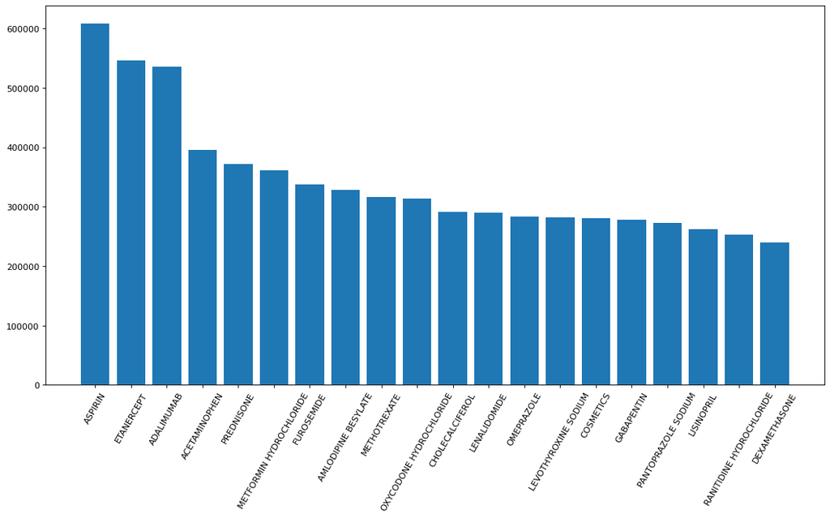

```python
plt.figure(figsize=(16, 8), dpi=80)
plt.bar(drug_counts_subset.substance, drug_counts_subset.drug_count)
plt.xticks(rotation = 60)
plt.show()
```

### 3. Explore which drugs are more commonly administered together with most observed drugs

```python
top_drugs = drug_agg_df['mapped_substance'].value_counts()[:30].index.tolist()
```

```python
drug_values = {}
for drug in top_drugs:
    rep_df = drug_agg_df[drug_agg_df['mapped_substance']==drug]
    rep_ids = set(rep_df['rep_id'].values)
    other_drugs_df = drug_agg_df[(drug_agg_df['rep_id'].isin(rep_ids)) & (drug_agg_df['mapped_substance'] != drug)]
    drug_values[drug] = other_drugs_df['mapped_substance'].value_counts()
```

### 4. Visualize which are the substances more often associated with the most observed substances

```python
# fig, axs = plt.subplots(5, 2)

fig = plt.figure(figsize=(30,60))
fig.set_dpi(180)
# fig.set_figheight(15)
# fig.set_figwidth(25)
i = 1
for drug in top_drugs[:10]:
    drug_together = drug_values[drug].to_frame()
    drug_together['substance'] = drug_together.index
    drug_together.rename(columns={'mapped_substance': 'drug_count'}, inplace=True)
    drug_together['percent'] = 100 * drug_together['drug_count'] / sum(drug_together['drug_count'])
    drug_together_subset = drug_together[:10]

    ax = fig.add_subplot(5,2,i)
    ax.bar(drug_together_subset.substance, drug_together_subset.percent)
    ax.set_title(drug, fontdict={'fontsize': 18})
    ax.tick_params(axis='x', labelsize=14, rotation = 60)
    ax.tick_params(axis='y', labelsize=14)
    ax.set_ylabel('Joint substance use (%)', fontdict={'fontsize': 18})
    i = i +1
# plt.figure()
plt.subplots_adjust(hspace=0.5)
plt.show()
```

[figure not shown]

# Extra: Time-dependant features

Another avenue that could be explored is how the incidence of certain drugs reported change yearly when compared to the total observations.

```python
drug_agg_df['year'] = drug_agg_df['receipt_date'].astype(str).str[:4]
```

```python
drug_year_df = drug_agg_df[['rep_id', 'year']].drop_duplicates()
aspirin_year_df = drug_agg_df[['rep_id', 'mapped_substance', 'year']].drop_duplicates()
yearly_observations = drug_year_df['year'].astype(int).value_counts()
yearly_observations_aspirin = aspirin_year_df[aspirin_year_df['mapped_substance']=='ASPIRIN']['year'].astype(int).value_counts()
```

```python
yearly_observations = yearly_observations.to_frame().rename(columns={'year': 'observation_count'})
yearly_observations_aspirin = yearly_observations_aspirin.to_frame().rename(columns={'year': 'observation_count'})

yearly_observations['Year'] = yearly_observations.index
yearly_observations_aspirin['Year'] = yearly_observations_aspirin.index
```

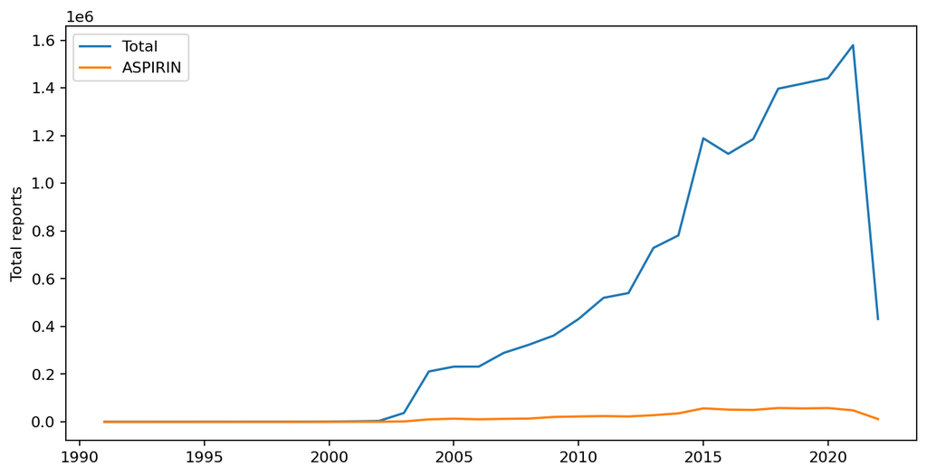

```python
yearly_observations = yearly_observations[(yearly_observations['Year'] > 1990) & (yearly_observations['Year'] <= 2022)].sort_values(by='Year')
yearly_observations_aspirin = yearly_observations_aspirin[(yearly_observations_aspirin['Year'] > 1990) & (yearly_observations_aspirin['Year'] <= 2022)].sort_values(by='Year')

plt.figure(figsize=(10, 5), dpi=160)
plt.ylabel('Total reports')
plt.plot(yearly_observations['Year'].values, yearly_observations['observation_count'].values, label="Total")
plt.plot(yearly_observations_aspirin['Year'].values, yearly_observations_aspirin['observation_count'].values, label="ASPIRIN")
plt.legend(loc="upper left")
```

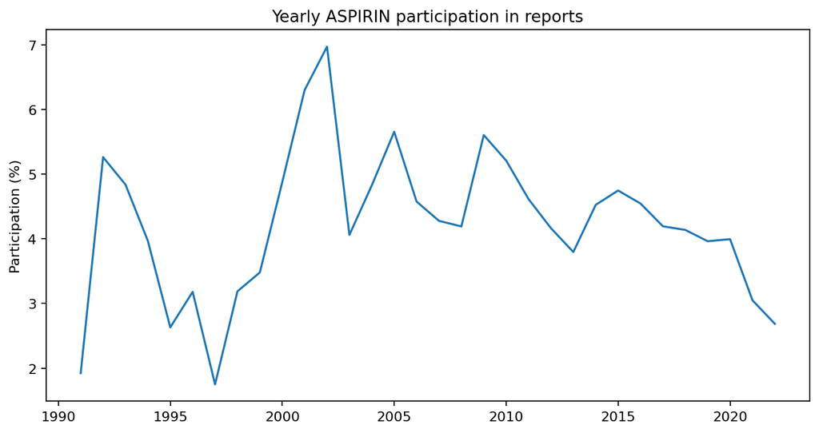

```python
yearly_observations['rel_aspirin'] = 100 * yearly_observations_aspirin['observation_count'] / yearly_observations['observation_count']

plt.figure(figsize=(10, 5), dpi=160)
plt.title('Yearly ASPIRIN participation in reports')
plt.ylabel('Participation (%)')
plt.plot(yearly_observations['Year'].values, yearly_observations['rel_aspirin'].values)
```